# Homework 3

Patrick Furman

2/17/2022

# Question 1

## A)

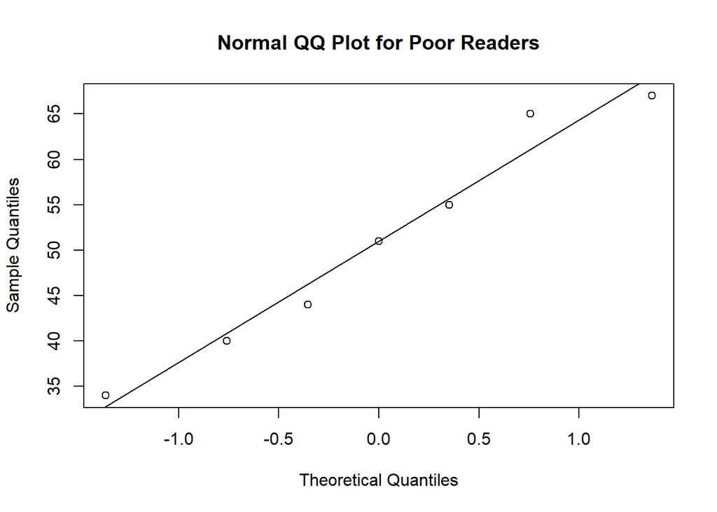

```r
# Create data vectors
poor = c(67, 55, 51, 40, 65, 34, 44)
normal = c(95, 87, 47, 55, 70, 42, 75, 88, 67, 54, 66, 75, 77, 81)

# Making plot
qqnorm(poor, main = "Normal QQ Plot for Poor Readers")
qqline(poor)
```

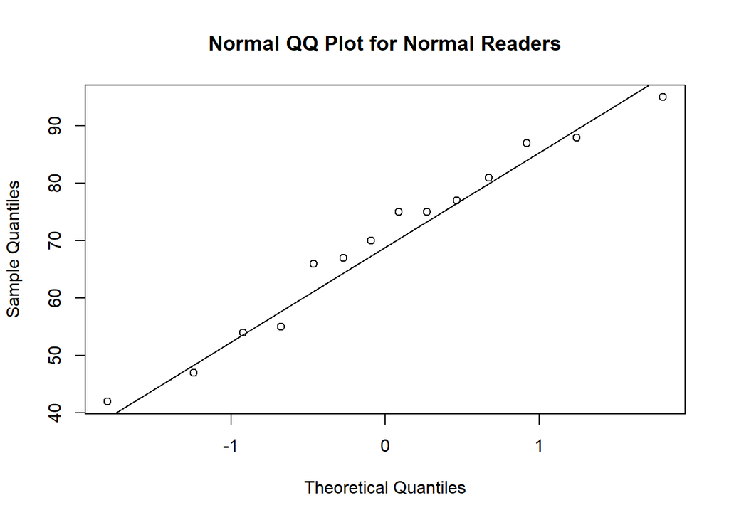

```r
qqnorm(normal, main = "Normal QQ Plot for Normal Readers")
qqline(normal)
```

Both the normal and poor reading groups have noticable “S” shapes in the QQ plot which would indicate non-normality but they stay close enough to the diagonal that they could still be normal given the small sample size.

## B)

```r
shapiro.test(poor)
```

```
##
##  Shapiro-Wilk normality test
##
## data:  poor
## W = 0.95109, p-value = 0.7396
```

```r
shapiro.test(normal)
```

```
##
##  Shapiro-Wilk normality test
##
## data:  normal
## W = 0.96725, p-value = 0.8379
```

$H_0:$ The distribution is normal $H_1:$ The distribution is not normal

With an alpha of 0.1, we fail to reject the null hypothesis for both poor and normal readers. We conclude in both cases that there is not enough evidence to suggest the distribution of reading skills is not normal.

## C)

```r
t.test(normal, poor)
```

```
##
##  Welch Two Sample t-test
##
## data:  normal and poor
## t = 3.0127, df = 15.135, p-value = 0.008674
## alternative hypothesis: true difference in means is not equal to 0
## 95 percent confidence interval:
##   5.58910 32.55376
## sample estimates:
## mean of x mean of y
##  69.92857  50.85714
```

$H_0:$ True difference in means is equal to zero

$H_1:$ True difference in means is not equal to zero

The p-value is below our alpha of 0.01 so we reject the null hypothesis and conclude that the there is a statistically significant difference between the mean reading score for the two groups.

## D)

```r
wilcox.test(normal, poor)
```

```
##
##  Wilcoxon rank sum test with continuity correction
##
## data:  normal and poor
## W = 82, p-value = 0.01522
## alternative hypothesis: true location shift is not equal to 0
```

$H_0:$ The distributions are identical

$H_1:$ The distributions have the same shape but are shifted

With an alpha of 0.01, we fail to reject the null and conclude that there is insufficient evidence to suggest that the distributions aren’t the same.

## E)

Although the QQ plots and shapiro-wilk tests indicated that the distributions were relatively close to normal, the small sample size makes the results somewhat questionable so I think the wilcoxon rank-sum test would be the more reliable in this case since we can’t be confident enough that the assumptions for the t-test are met.

# Question 2

## A)

```r
exposed = c(35, 56, 83, 92, 128, 150, 176, 208)
unexposed = c(8, 11, 12, 14, 20, 43, 111)
t.test(exposed, unexposed, mu=25, alternative='greater')
```

```
##
##  Welch Two Sample t-test
##
## data:  exposed and unexposed
## t = 2.3493, df = 11.817, p-value = 0.01853
## alternative hypothesis: true difference in means is greater than 25
## 95 percent confidence interval:
##  39.35281      Inf
## sample estimates:
## mean of x mean of y
## 116.00000  31.28571
```

$H_0:$ True difference in means is less than or equal to 25

$H_1:$ True difference in means is greater than 25

With an alpha of 0.05, we reject the null and conclude that average cotanine levels of those exposed to smoking is greater than those not exposed by more than 25.

## B)

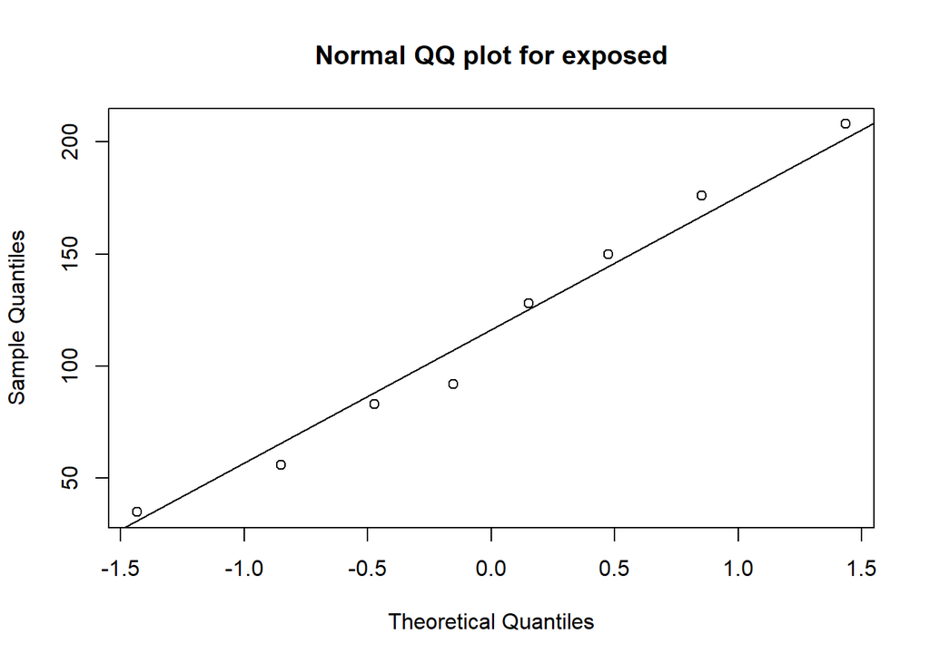

```r
# QQ plots
qqnorm(exposed, main="Normal QQ plot for exposed")
qqline(exposed)
```

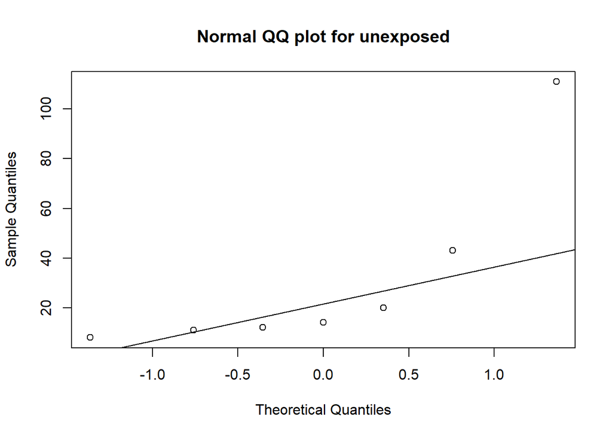

```r
qqnorm(unexposed, main="Normal QQ plot for unexposed")
qqline(unexposed)
```

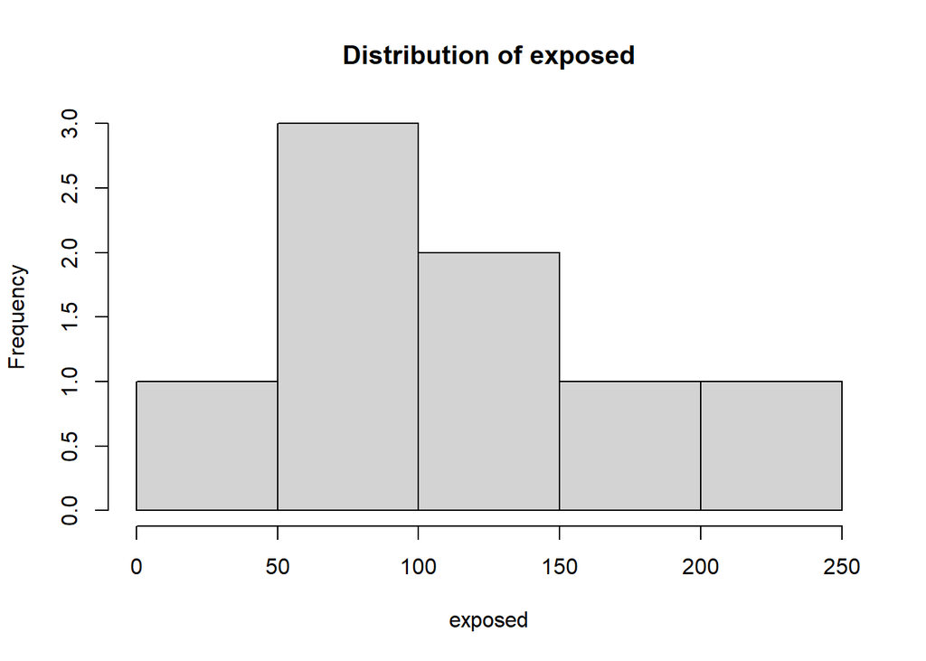

```r
# Histograms
hist(exposed, main="Distribution of exposed")
```

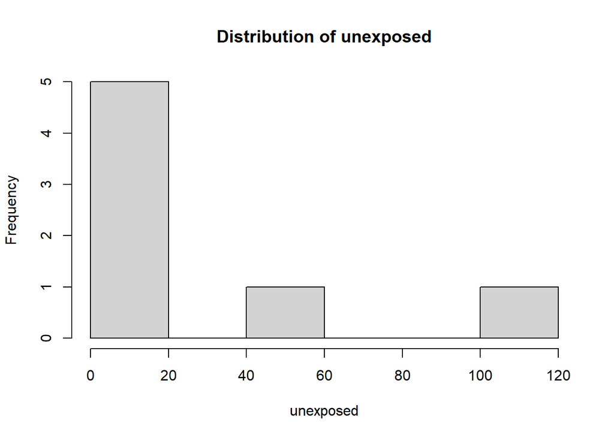

```r
hist(unexposed, main="Distribution of unexposed")
```

```r
# Shapiro test
shapiro.test(exposed)
```

```
##
##  Shapiro-Wilk normality test
##
## data:  exposed
## W = 0.97103, p-value = 0.906
```

```r
shapiro.test(unexposed)
```

```
##
##  Shapiro-Wilk normality test
##
## data:  unexposed
## W = 0.68246, p-value = 0.002378
```

The unexposed group is clearly very far from a normal distribution which we can see from the shapiro-wilk test and the normal QQ plot and the sample size is also very small so we fail to meet the normality assumption for the t-test to be reliable.

## C)

```r
permute_2 = function(x, data, categorical) {
  # Randomly order data
  data = sample(data, length(data))

  # Create anova
  a = anova(lm(data~categorical))

  # Return F from anova
  return(a$'F value'[1])
}

p_value = function(f_obs, f_perm) {
  return(sum(f_perm >= f_obs) / length(f_perm))
}

# Combine data and adjust exposed data by 25
full = c(exposed-25, unexposed)
categories = as.factor(c(rep(1, length(exposed)), rep(2, length(unexposed))))

# Run above method for 5000 permutations
n_perm = 5000
f_perm = rep(0, n_perm)
f_perm = sapply(f_perm, FUN=permute_2, data = full, categorical = categories)

# Displaying results
cat("P-value:", p_value(anova(lm(full~categories))$'F value'[1], f_perm))
```

```
## P-value: 0.0394
```

$H_0:$ The mean concentration for those exposed is less than or equal to 25

$H_1:$ The mean concentration for those exposed is greater than 25

## D)

```r
alt_exposed = exposed - 25
wilcox.test(alt_exposed, unexposed, alternative='greater')
```

```
##
##  Wilcoxon rank sum exact test
##
## data:  alt_exposed and unexposed
## W = 45, p-value = 0.02704
## alternative hypothesis: true location shift is greater than 0
```

```r
# testing alternative way of doing the same test
wilcox.test(exposed, unexposed, mu=25, alternative='greater')
```

```
##
##  Wilcoxon rank sum exact test
##
## data:  exposed and unexposed
## W = 45, p-value = 0.02704
## alternative hypothesis: true location shift is greater than 25
```

$H_0:$ True location shift is less than or equal to 25

$H_1:$ True location shift is greater than 25

With a p-value of 0.027 we reject the null and conclude that the median of those exposed is greater than those unexposed by more than 25.

## E)

```r
ansari.test(exposed, unexposed)
```

```
##
##  Ansari-Bradley test
##
## data:  exposed and unexposed
## AB = 37, p-value = 0.5958
## alternative hypothesis: true ratio of scales is not equal to 1
```

$H_0:$ The distributions have the same scale

$H_1:$ The distributions do not have the same scale

Our p-value is 0.5958 which is greater than our alpha of 0.05 so we fail to reject the null and conclude there is insufficient evidence to suggest the distributions have different scales.

# Question 3

## A)

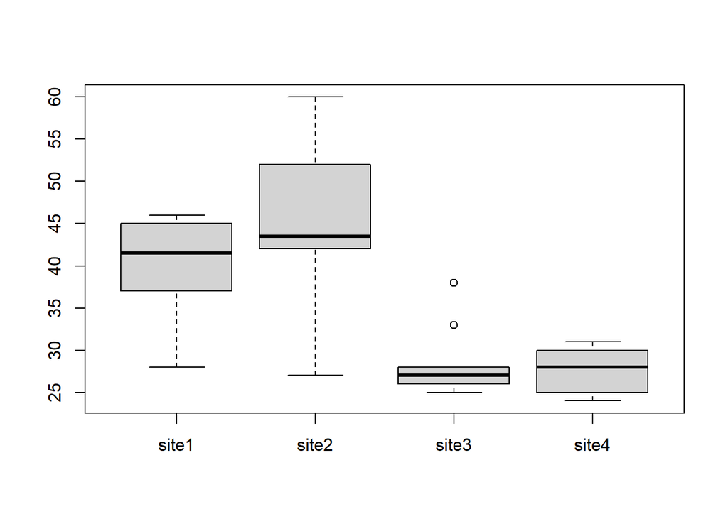

```r
site1 = c(46, 28, 46, 37, 32, 41, 42, 45, 38, 44)
site2 = c(42, 60, 32, 42, 45, 58, 27, 51, 42, 52)
site3 = c(38, 33, 26, 25, 28, 28, 26, 27, 27, 27)
site4 = c(31, 30, 27, 29, 30, 25, 25, 24, 27, 30)
sites = data.frame(site1=site1, site2=site2, site3=site3, site4=site4)
boxplot(sites)
```

Each site appears to have a significantly different distribution both in scale and shape. Sites 3 and 4 have similar medians to each other and sites 1 and 2 are also more similar to one another but there’s a significant difference in scale between the first 2 and last 2 sites. Additionally, site 2 appears very right skewed while site 3 looks fairly symmetric disregarding the outliers and sites 1 and 4 appear slightly left skewed.

## B)

```r
site_num = as.factor(c(rep(1, 10), rep(2, 10), rep(3, 10), rep(4, 10)))
site_vector = c(site1, site2, site3, site4)

a = anova(lm(site_vector~site_num))
```

$H_0:$ The mean for each site is equal

$H_1:$ At least one of the means is different

## C)

```r
permute = function(x, data) {
  # Randomly order data
  data = sample(data, length(data))

  # Create anova
  a = anova(lm(data~site_num))

  # Return F from anova
  return(a$'F value'[1])
}

n_perm = 10000
f_perm = rep(0, n_perm)
f_perm = sapply(f_perm, FUN=permute, data = site_vector)

cat("P-value:", p_value(a$`F value`[1], f_perm))
```

```
## P-value: 0
```

$H_0: \tau_1 = \tau_2 = ... = \tau_k$

$H_1:$ at least one $\tau$ is different

The p-value is 0 so we reject the null and conclude that the distributions between sites are shifted for at least one site

## D)

```r
kruskal.test(sites)
```

```
##
##  Kruskal-Wallis rank sum test
##
## data:  sites
## Kruskal-Wallis chi-squared = 22.852, df = 3, p-value = 4.335e-05
```

$H_0:$ The median for each group is the same

$H_1:$ At least one median is different

Our p-value is 4.335e-05 which is well below our alpha of 0.05 so we reject the null and conclude that at least one site has a median different from the others.

## E)

```r
shapiro.test(site1)
```

```
##
##  Shapiro-Wilk normality test
##
## data:  site1
## W = 0.89583, p-value = 0.1971
```

```r
shapiro.test(site2)
```

```
##
##  Shapiro-Wilk normality test
##
## data:  site2
## W = 0.95306, p-value = 0.7048
```

```r
shapiro.test(site3)
```

```
##
##  Shapiro-Wilk normality test
##
## data:  site3
## W = 0.74631, p-value = 0.003218
```

```r
shapiro.test(site4)
```

```
##
##  Shapiro-Wilk normality test
##
## data:  site4
## W = 0.89529, p-value = 0.1944
```

None of the methods meet all their assumptions so I don’t think it’s a clear choice on which is best. The shapiro test indicates that there’s strong evidence that at least site 3 is not normally distributed so the assumptions for ANOVA aren’t met. However, judging from the boxplots of the data, the shape of the distribution for each site doesn’t look very similar which is required for the permutation and kruskal-wallis tests. Overall, because of the low sample size, I would use either the permutation test or the kruskal-wallis test but they still aren’t ideal.